# Analyzing Conference Disparity in the NBA with R

Mein En Lee

02/23/22

# Introduction

Using data from the 2005-06 to 2020-21 NBA seasons, I analyzed conference disparity in the NBA. How strong is the conference disparity? Is the disparity significant? Is it getting worse?

Throughout this project, there are guiding questions on how to apprach the datasets. Based on the analysis, I recommended Machine Learning models in order to make data-driven decisions within the NBA.

**Note:**

Throughout this document, the `season` column represents the year each season started. For example, the most recently completed season, 2020-2021, is in the data as season = 2020.

# Datasets

Please check out my github repository: github.com/mein-lee/NBA_conference_disparity to view the datasets.

combined_team_vs_team_records.csv' has rows for each team in each season with columns representing matchup records against every team in the NBA in that season. For example, the 2016-17 Golden State Warriors won all four regular season matchups against the Los Angeles Clippers. Therefore the 'LAC' column of the 2016 Warriors row contains the value '4-0'. Let's get started!

# Guiding Questions

**Question 1-6: Conference Standings**  
Overall win % of teams in the Western Conference against teams in the Eastern Conference  
Year where the Western Coference had more wins than losses against the East  
Year with the most extreme disparity, inter conference win-loss record  
Playoff team with the lowest win % in each conference  
Graph showing the win % of playoff and non-playoff teams among Conferences  
Takeaways from Win % visualizations  
**Questions 7-10: Point margin and strength of schedule**  
Examine teams' opponents' point margins and strength of schedule  
Takeaway from point margin visualizations  
Takeaway from srength of schedule visualizations  
**Questions 11 - 15: Logistic Regression and Hypothesis Testing**  
Year with the most extreme disparity, inter conference win-loss record  
**Questions 16 - 17: Case Studies**  
Case Study Question on Rookie picks  
Case Study Question on offensive rebound strategy

```r
library(tidyverse)
standings <- read_csv("combined_standings.csv")
team_v_team <- read_csv("combined_team_vs_team_records.csv")
```

# Conference Standings

### Question 1

**QUESTION:** What is the overall win % to one decimal place (e.g. 41.3%, 74.9%) of teams in the Western Conference against teams in the Eastern Conference through the 2005-2020 regular seasons? If the West has more wins than losses against the East, your answer should be a number greater than 50% and vice versa.

```r
joined <- merge(standings, team_v_team, by = c("season", "bb_ref_team_name"))
joined[is.na(joined)] = "0-0"

# Remove West teams to form West-East dataframe
west_only <- joined[joined$conference == "West",]
west_teams <- unique(west_only$team_short)
west_east <- west_only[, !(colnames(west_only) %in% west_teams)]

# Use substring to sum wins and losses
wins <- 0
loss <- 0
nrows <- c(1:nrow(west_east))
for (row in nrows){
  wins <- wins + sum(as.numeric(substring(west_east[row,12:26],1,1)))
  loss <- loss + sum(as.numeric(substring(west_east[row,12:26],3,3)))
}

overall <- round((sum(wins) / sum(wins + loss))*100, 1)
```

**ANSWER 1:** 55.7%

### Question 2

**QUESTION:** Out of the past 16 years (2005-2020), how many years has the Western Conference had more wins than losses against the East?

```r
# Group by (season, conference) and calculate win_pct of each group
group_season_conference <- standings %>%
                        group_by(season, conference) %>%
                        summarise(wins_sum = sum(wins),
                                  losses_sum = sum(losses),
                                  group_win_pct = wins_sum /
                                    (wins_sum + losses_sum))
# Determine conference with higher win_pct of each season
higher_win_pct <- group_season_conference %>%
              group_by(season) %>%
              slice(which.max(group_win_pct))

# Number of times each conference has more wins than losses (higher win_pct)
table(higher_win_pct$conference) %>% as.data.frame()
```

```
##   Var1 Freq
## 1 East    1
## 2 West   15
```

**ANSWER 2:** 15 out of 16 years.

### Question 3

**QUESTION:** In which year was the disparity between the conferences most extreme? What was the inter conference win-loss record (in the format WEST WINS - EAST WINS) in that year?

```r
# Calculate disparity within conferences throughout the seasons
disparity_df <- group_season_conference %>%
          group_by(season) %>%
          summarise(conference, wins_sum, disparity = diff(wins_sum)) %>%
          arrange(desc(disparity))
head(disparity_df, 2)
```

```
## # A tibble: 2 x 4
## # Groups:   season [1]
##   season conference wins_sum disparity
##    <dbl> <chr>         <dbl>     <dbl>
## 1   2013 East            556       118
## 2   2013 West            674       118
```

### Question4

**QUESTION:** For each season, find the playoff team with the lowest win % in each conference. What is the average win % of these teams from each conference over the 2005-2020 time period? In the case of ties within a season/conference pair, choose just one team.

For example, from the 2020 season, we would include Memphis from the West (38-34, 52.8%) and Washington from the East (34-38, 47.2%).

```r
playoff_teams <- standings[standings$playoffs == "Yes",]

#Playoff teams with the lowest win % in each conference throughout the seasons
lowest_win_pct <- playoff_teams %>%
                group_by(season, conference) %>%
                slice(which.min(win_pct))

# Average win % of these teams from each conference
lowest_win_pct %>%
          group_by(conference) %>%
          summarise(average_win_pct = mean(win_pct))
```

```
## # A tibble: 2 x 2
##   conference average_win_pct
##   <chr>                <dbl>
## 1 East                 0.485
## 2 West                 0.551
```

### Question 5

**QUESTION:** Create a ggplot graph showing the record / win % of playoff and non-playoff teams against playoff and non-playoff teams from the **other** conference each season.

For example, your graph should include a visual representation of how Western Conference playoff teams have done against Eastern Conference non-playoff teams each season (as well as other combinations of conference and playoffs).

**ANSWER 5:**

```r
east_only <- joined[joined$conference == "East",]
west_east <- west_east[12:26]

west_east$season <- west_only$season
west_east$playoffs <- west_only$playoffs
west_east <- west_east[,c(1:3,5,4,6:17)]
w_east_playoffs <- west_east # Make a copy

# Eastern Conference Playoff teams
for (year in seq(1,240,by=15)){
  for (i in c(0:14)){
    if(east_only$playoffs[i+year] == 'No'){
      w_east_playoffs[seq(year,year+14),i+1] = '0-0'
    }
  }
}

# Row sum for wins and losses
for (i in c(1:240)){
  w_east_playoffs$wins[i] <- sum(as.numeric(substring(w_east_playoffs[i,1:15],1,1)))
  w_east_playoffs$losses[i] <- sum(as.numeric(substring(w_east_playoffs[i,1:15],3,3)))
}

# West vs. East teams, grouped by playoffs/lottery
w_east_playoffs <- w_east_playoffs %>%
  group_by(playoffs) %>%
  mutate(East='Playoffs', winpct = wins/(wins+losses)) %>%
  select(wins, losses, East, winpct)
w_east_lotto <- west_east

for (year in seq(1,240,15)){
  for (i in c(0:14)){
    if(east_only$playoffs[i+year] == 'Yes'){
      w_east_lotto[seq(year,year+14),i+1] = '0-0'
    }
  }
}

for (i in c(1:240)){
  w_east_lotto$wins[i] = sum(as.numeric(substring(w_east_lotto[i,1:15],1,1)))
  w_east_lotto$losses[i] = sum(as.numeric(substring(w_east_lotto[i,1:15],3,3)))
}

w_east_lotto <- w_east_lotto %>%
  group_by(playoffs) %>%
  mutate(East='Lotto', winpct = wins/(wins+losses)) %>%
  select(wins, losses, East, winpct)
```

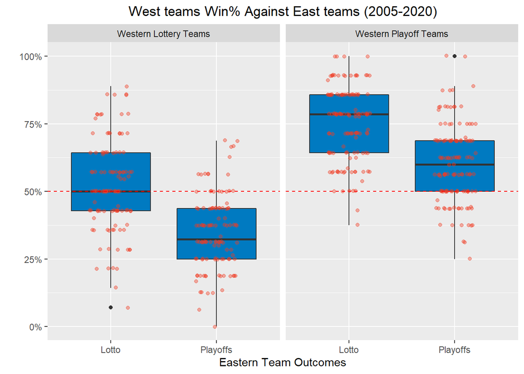

```r
fullwVe <- rbind(w_east_lotto, w_east_playoffs)

plot <- fullwVe %>%
  mutate(playoffs = ifelse(playoffs=='Yes','Western Playoff Teams','Western Lottery Teams')) %>%
  ggplot(aes(x=East,y=winpct,fill=playoffs))+
  labs(title='West teams Win% Against East teams (2005-2020)', x='Eastern Team Outcomes',y='')+
  geom_boxplot(fill='#007AC1')+
  geom_jitter(width=.2,alpha=.4,color='#EF3B24')+
  facet_wrap(~playoffs)+
  geom_hline(yintercept=.5, color='red', linetype='dashed')+
  theme(legend.position = 'none', plot.title = element_text(hjust=.5))+
  scale_y_continuous(labels=scales::percent)

plot
```

### Question 6

**QUESTION:** Write up to two sentences describing any takeaways you have from your visual above that you could send in a group email to the data science department.

**ANSWER 6:** Over the past 16 NBA seasons, inter-conference regular season matchups of two eventual playoffs/lottery teams have swung in favor of the Western Conference. In addition, the skill gap between playoff teams from East vs. West has been closer than Western Conference playoff teams vs. Eastern lottery opponents.

# Point Margins and Schedules

### Question 7

In this next series of questions we are going to look at the strength of schedule by examining teams’ opponents’ point margins.

First, calculate the average point margin for each team’s opponents in each year, weighting by the number of times the teams played. For example, if team A played against team B once and team C twice, and team B had a season average point margin of +2 and team C had a season average point margin of -3, team A’s opponents would have an average point margin of (2 - 3 - 3) / 3 = -1.33. There is no need to display the results of this calculation here, you are going to use it for the next few questions.

```r
# Rearrange columns
joined <- joined[,c(1:14,16,15,17:41)]

# Total games played with each opponent
for (col in c(12:41)){
  joined$opp <- (as.numeric(substring(joined[,col],1,1))
                + as.numeric(substring(joined[,col],3,3)))
  # Rename new columns
  colnames(joined)[ncol(joined)] <- paste("total_",
                                          colnames(joined)[col], sep="")
}
# Total games played with opponents
joined$total_games <- apply(joined[,c(42:71)], 1, sum)

# Point margin of each team throughout the seasons
joined$point_margin <- (joined$points_scored_per_game -
                        joined$points_allowed_per_game)

# Use nested for-loop for total opponent point margin
joined$total_opp_point_margin <- 0
for (season in seq(1,480,30)){
  for(opp in c(0:29)){
    for (team in c(0:29)) {
    joined$total_opp_point_margin[season+opp] <-
      (joined$total_opp_point_margin[season+opp] +
       joined$point_margin[season+team] *
         joined[season+opp, team+42])
    }
  }
}
# Opponent's average point margin
joined$oppAv_pm <- joined[,74] / joined[,72]
```

**QUESTION:** What was OKC’s opponents’ average point margin (to two decimal places) in the 2016 season?

```r
okc_opp_av_pm <- round((joined[(joined$team_short == 'OKC') & (joined$season == 2016),75]),2)
```

**ANSWER 7:** 0.32

### Question 8

**QUESTION:** As close as you can, reproduce the following plot. There is one point on the plot for each team/season combination.

**ANSWER 8:**

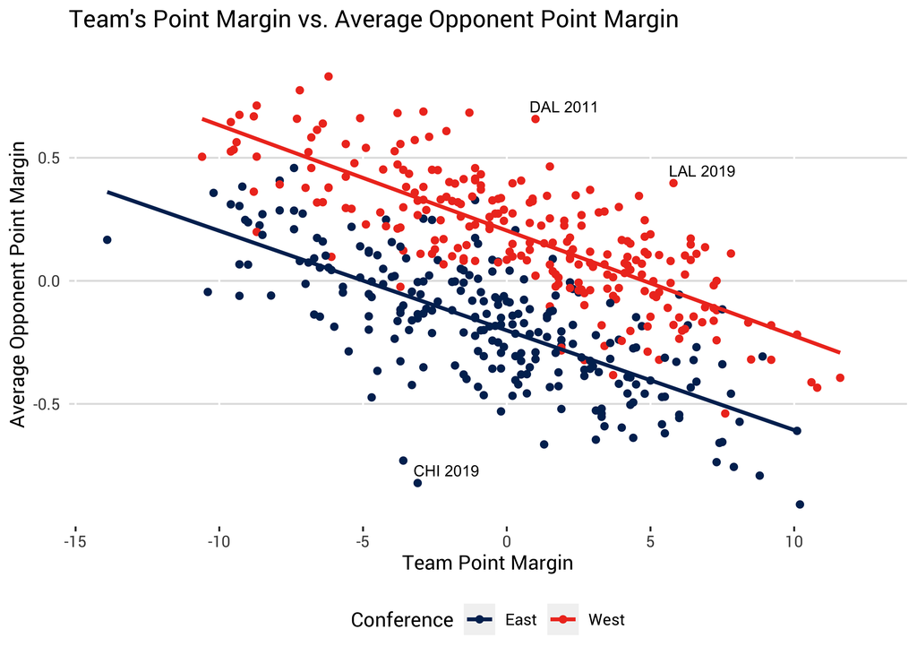

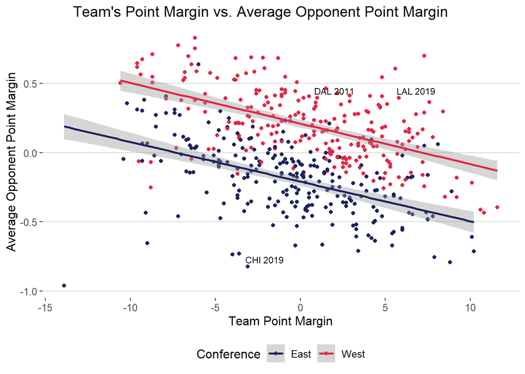

```r
joined$team_year <- paste(joined$team_short, joined$season)

# Filter for outliers
outliers <- joined %>% filter(team_year %in% c('DAL 2011','LAL 2019','CHI 2019'))

#Plot
library(ggthemes)
answer_q8 <- joined %>%
  ggplot(aes(x=points_scored_per_game-points_allowed_per_game, y=oppAv_pm, color=conference))+
  geom_point()+
  geom_text(aes(label=team_year), data=outliers, nudge_y = .05,nudge_x = 1.0,color='black',size=3)+
  scale_color_manual(values = c('#1d235e','#e32745'))+
  geom_smooth(formula = y ~ x, method = "lm")+
  labs(x='Team Point Margin', y='Average Opponent Point Margin', title="Team's Point Margin vs. Average Opponent Point Margin",
       color='Conference')+
  theme(legend.position = 'bottom', plot.title = element_text(hjust=.3))+
  theme_hc()
answer_q8
```

### Question 9

**QUESTION:** Write no more than 4 sentences explaining this plot and two takeaways to a non-technical member of the organization.

**ANSWER 9:** The dots on the plot represent teams from the 2005-2020 NBA seasons, colored based on their conference. A team’s point margin increases along the horizontal axis, whereas a team’s strength of schedule increases along the vertical axis. The placement of most red dots suggest a tougher strength of schedule for Western Conference teams than Eastern Conference teams.

### Question 10

**PART (a):** What do you conclude about the relative strength of schedule for the two labeled teams (DAL 2011 and LAL 2019) (compared to all the rest of the teams) at the top of the plot? Please answer in 1 sentence.

**ANSWER 10 (a):** Compared to other teams, the two labelled teams had a tough schedule due to their opponents’ high point margins.

**PART (b):** Do you have any hypotheses as to why teams from 2019 and 2011 appear at the extremes of this graph? Please answer in no more than 3 sentences.

**ANSWER 10 (b):** An NBA Lockout occurred in 2011, and the Covid-19 pandemic have impacted the 2019-2020 NBA season. Both events caused teams to play fewer games, and a small sample of games fails to standardize team point margins. This produces abnormal values that are plotted at the extremes of this graph.

# Logistic Regression

### Question 11

**QUESTION:** Fit a logistic regression model on all of the data 2005-2020 predicting the chance a team makes the playoffs from only its win % in that season. What are the coefficients?

```r
joined$playoffs <- as.factor(joined$playoffs)
reg <- glm(playoffs ~ win_pct, data=joined, family = 'binomial')
aa <- reg$coefficients[1] #intercept
bb <- reg$coefficients[2] #win_pct
```

**ANSWER 11:** Intercept: -20.88, win_pct: 42.40

### Question 12

**QUESTION:** Using your model from the previous question, what is the probability that a team with exactly a 50% win rate will make the playoffs (rounded to the nearest decimal, e.g. 44.7%)?

```r
round(exp(aa+bb*.5)/(1+exp(aa+bb*.5))*100,1)
```

```
## (Intercept)
##          58
```

**ANSWER 12:** 58.0%.

### Question 13

Add a indicator variable called `is_west` to your regression model that is TRUE if the team is in the Western Conference.

```r
joined$west <- as.factor(ifelse(joined$conference=='West',1,0))

reg_conf <- glm(playoffs ~ win_pct + west, data=joined, family = 'binomial')
```

**QUESTION:** What is the `is_west` coefficient and what does it mean? What is the prediction to the nearest decimal for a team in the East and a team in the West with a 50% win rate?

```r
round(reg_conf$coefficients[3],3)
```

```
##  west1
## -2.875
```

```r
a <- reg_conf$coefficients[1]
b <- reg_conf$coefficients[2]
c <- reg_conf$coefficients[3]

west <- round(exp(a+b*.5+c)/(1+exp(a+b*.5+c))*100,1)
east <- round(exp(a+b*.5)/(1+exp(a+b*.5))*100,1)
```

**ANSWER 13:**  
The coefficient is -2.875. Explanation: Controlling for win_pct, the predicted chance of a team making the playoffs decrease by 2.875 with a switch from the Eastern to the Western Conference. EAST: 83.4%  
WEST: 22.1%

### Question 14

We are going to investigate whether it’s possible that the relationship you found in the previous question could be reasonably explained by randomness. We’re only looking at 30 teams over 16 years, so sample size might be a concern. To do this, you will perform a permutation test.

For each of 10,000 iterations, randomly reorder the conference labels so that in each iteration, there are 15 random teams labeled as East and 15 teams labeled as West. For example, in a given iteration, we might have assigned OKC to the East and BKN to the West, but MIA might still be assigned to East. For each iteration, fit a new logistic regression model with the same variables as in question 13 (predicting making the playoffs from win % and `is_west`) and extract the `is_west` coefficient. Save all 10,000 `is_west` coefficients in a vector or dataframe.

```r
set.seed(425)
joined$sim_conf <- 0
sim_df <- joined[, c("win_pct", "playoffs")]
iswest_coef <- c()

for (iter in c(1:10000)) {
  # Get random row indices, assign to West
  assign_west <- sample(1:30,15)
  row <- rep(0,30)
  row[assign_west] <- 1
  sim_df$is_west <- rep(row,16)
  #Fit logistic regression
  reg_sim <- glm(playoffs ~ win_pct + is_west,
                 data=sim_df, family ='binomial')
  # Extract coefficient
  iswest_coef[iter] <- reg_sim$coefficients[3]
}
```

**PART (a):** Make a ggplot comparing these 10,000 randomized `is_west` coefficients to the `is_west` coefficient you observed in question 13.

**ANSWER 14 (a):**

[figure not shown]

```r
iswest_coef <- as.data.frame(iswest_coef)
iswest_coef$Style <- 'Simulation'

plot_q14 <- iswest_coef %>%
  ggplot(aes(x=iswest_coef, fill=Style))+
  geom_histogram(bins = 100)+
  xlim(-3,2)+
  ylim(0,300)+
  geom_segment(aes(y=75, xend=-2.75, x=-2.5,yend=20),
               arrow = arrow(length=unit(.5, 'cm')))+
  annotate('text', x=-2.875,y=90, label='Observed Coefficient', size=3)+
  labs(x='Western Conference Log Odds Effect on Playoff Chances (Controlled for Win%)',
       y='Count',
       title='1000 Simulations of Playoff Chances from randomly assigned conference')+
  theme_hc()+
  theme(legend.position = 'none', plot.title = element_text(hjust=.5), plot.subtitle = element_text(hjust=.5))
plot_q14
```

# Short Answer (Modeling)

### Question 15

Two rookies come into the league and each play the same number of minutes. Rookie A shot 37/100 from 3 and rookie B shot 20/50 from 3. The general manager asks you which player you expect to be a better three point shooter long term. You have a week to work on this hypothetical project.

**PART (a):** What kind of data and information would you collect in order to answer this? Describe the features you’d use and the model you’d build to answer the question. You don’t need to actually do the work here, just describe your process. Please limit your response to no more than 5 sentences.

**ANSWER 15 (a):** Features: 3PT%, FT%, and a delta parameter for each feature to track the change in a player’s shooting percentage from his first to last college season. Using college 3PT% on its own is not a good predictor because the three-point line distance is different than NBA’s, but FT% will demonstrate a prospect’s pure form. A Decision tree model of depth 5 would predict what quartile a player’s 3-point shooting percentage would be, which would indicate whether a player will be a serviceable 3-point shooter.

**PART (b):** If you had to choose today without doing any further research, would you pick player A or player B? Why? Please limit your response to no more than 2 sentences.

**ANSWER 15 (b):** Player A attempted more shots within the same time frame, shows agility and ability to perform under pressure, and provides a larger sample size.

### Question 16

**QUESTION:** You are studying offensive rebounding as part of your job as Data Analyst with an NBA team. You are trying to create a model that will help predict when there will be an offensive rebound.

Your first model is a GBM (gradient boosted machine) that includes the location data (at the time the ball hits the rim) and height for all 10 players on the floor. It outputs a prediction for the percentage chance each player will collect the rebound.

Your second model is a logistic regression model that includes the shot distance, the number of players who crash the boards, and the distance to the rim for the closest two offensive and defensive players. This model outputs a prediction for the percentage chance the offensive team secures the rebound.

In no more than 4 sentences, how would you decide which model to move forward with? Why?

**ANSWER 16:** Logistic regression uses features that seem to be better predictors. This model also provides a more straightforward prediction than GBM.

### Question 17

**QUESTION:** Your coach hears about the project and is interested in the tradeoffs between offensive rebounding and transition defense. He asks you to expand the research you have been doing into a study to help him determine when/how many players he should send to crash the offensive boards.

How would you use one of the models described above to answer the question for the coach? (Please select one of the two models to write about for this portion of the question.) What other research would be necessary to effectively answer this question for the coach? Describe, in general terms, your plan to answer the coach’s question and what you would plan to present to him. Please answer this question in no more than 6 sentences.

**ANSWER 17:** First, we should study the correlation between the number of “crashers” on each missed shot and the opponent’s subsequent transition offensive opportunity. The data to collect will be: 1) Type of shot taken, 2) Number of players crashed, 3) Did they rebound? If so did they score?, 4) If they did not rebound, did the opponent get a transition opportunity?, and 5) Did they score off that Transition Opportunity? If the study shows an inverse relationship between number of “crashers” and the opponent’s subsequent transition offensive opportunity, and if the logistic regression model from Q16 predicts a high percentage chance the offensive team secures the rebound, then the coach should place greater emphasis on crashing the board.